# Assignment-03_Bukva

#Assignment 03 - Use the attrition dataset to answer the following questions.

Today we will use RSudio to do the following tasks:

```
1. Create a graph that shows the distribution of monthly income
2. Create a graph that shows the average level of monthly income by field of education.
3. Create another graph that shows average level of monthly income by field of education and gender.
4. Create a graph that shows average levels of monthly income by field of education, gender and job level (scale  of 1-5, highest ranked employees are 5)
```

First we will need to load the data from the Week 3 asyn called at dataset as well as packages for RStudio

```r
load("attrition.Rdata")
```

##Part 1 - Create a graph that shows the distribution of monthly income

Using a histogram, I was able to show the distribution of the monthly income. I thought the histogram looked better because it would show a continuous variable better across the range of incomes.

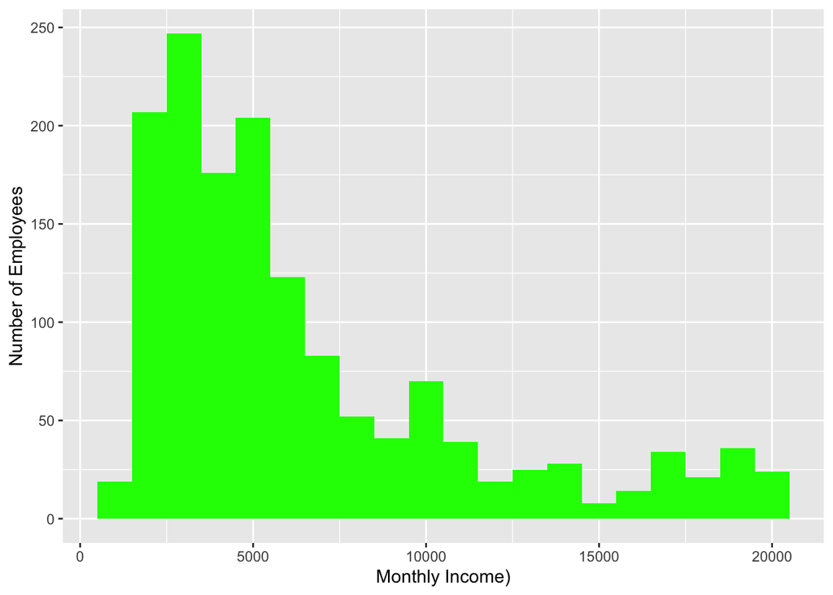

```r
gg<-ggplot(at,aes(x=MonthlyIncome))
gg<-gg+geom_histogram(binwidth = 1000,fill="green")
gg<-gg+xlab("Monthly Income)")+ylab("Number of Employees")
gg
```

##Part 2 - Create a graph that shows the average level of monthly income by field of education.

First we make a prediction of the average income by education field and we name that inc_avg. We then utilize a bar chart to show the average level of income by the employees particular field of education. After using the summary data to plot on the bar graph, we find that individuals with a degree in Marketing make the most income followed closely by those with a Human Resources degree.

```r
at_sum<-at%>%
  group_by(EducationField)%>%
  summarize(inc_avg=mean(MonthlyIncome))

at_sum
```

```
## # A tibble: 6 x 2
##   EducationField   inc_avg
##   <chr>              <dbl>
## 1 Human Resources    7241.
## 2 Life Sciences      6463.
## 3 Marketing          7349.
## 4 Medical            6510.
## 5 Other              6072.
## 6 Technical Degree   5758.
```

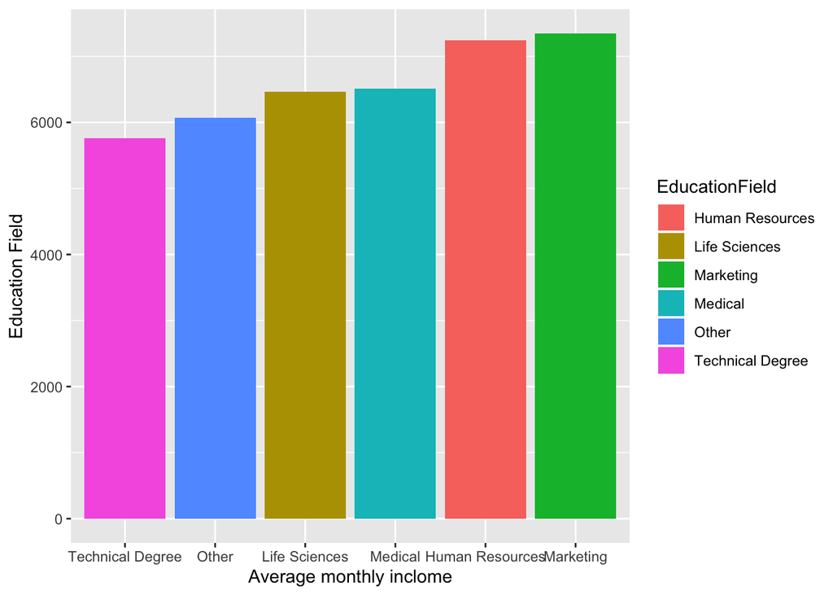

```r
gg<-ggplot(at_sum,aes(x=fct_reorder(EducationField,inc_avg),y=inc_avg))
gg<-gg+geom_bar(stat="identity",aes(fill=EducationField),position="dodge")
gg1<-gg+xlab("Average monthly inclome")+ylab("Education Field")
gg1
```

##Part 3 - Create another graph that shows average level of monthly income by field of education and gender.

Again we will make a prediction of average income by both education level and gender this time. We will then add a variable gender to the bar plot that we make. In doing so we will see that men only outearn women with degrees in life sciences and every other field we see women outearning men.

```r
at_sum1<-at%>%
  group_by(EducationField,Gender)%>%
  summarize(inc_avg=mean(MonthlyIncome))%>%
  arrange(-inc_avg)

at_sum1
```

```
## # A tibble: 12 x 3
## # Groups:   EducationField [6]
##    EducationField   Gender inc_avg
##    <chr>            <chr>    <dbl>
##  1 Human Resources  Female   9568.
##  2 Marketing        Female   7586.
##  3 Marketing        Male     7167.
##  4 Technical Degree Female   7148.
##  5 Medical          Female   6520.
##  6 Medical          Male     6503.
##  7 Life Sciences    Male     6483.
##  8 Life Sciences    Female   6433.
##  9 Human Resources  Male     6262.
## 10 Other            Female   6114.
## 11 Other            Male     6048.
## 12 Technical Degree Male     4855.
```

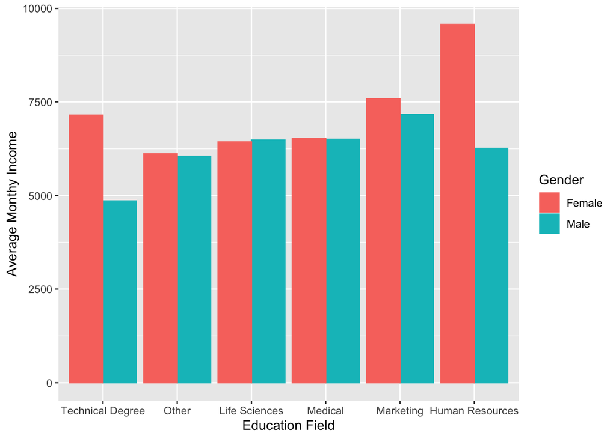

```r
gg<-ggplot(at_sum1,aes(x=fct_reorder(EducationField,inc_avg),y=inc_avg,color=Gender))
gg<-gg+geom_bar(stat="identity",aes(fill=Gender),position="dodge")
gg2<-gg+ylab("Average Monthy Income")+xlab("Education Field")
gg2
```

##Part 4 - Create a graph that shows average levels of monthly income by field of education, gender and job level (scale of 1-5, highest ranked employees are 5)

Again we make a prediction. This time we find average income when considering education field, gender, and job level. Then using the facet command we will plot sub-bar plots to see the data separated, yet still grouped together on the same page. Once doing so, we find that at the beginning and ending levels of jobs there is little deviation based on gender and education, yet in the middle ranges 3 & 4 we do see some variance due to gender and/or field of education.

```r
at_sum2<-at%>%
  group_by(EducationField,Gender,JobLevel)%>%
  summarize(inc_avg=mean(MonthlyIncome))%>%
  arrange(-inc_avg)

at_sum2
```

```
## # A tibble: 58 x 4
## # Groups:   EducationField, Gender [12]
##    EducationField   Gender JobLevel inc_avg
##    <chr>            <chr>     <int>   <dbl>
##  1 Technical Degree Female        5  19744
##  2 Other            Male          5  19443.
##  3 Human Resources  Male          5  19322
##  4 Medical          Male          5  19251.
##  5 Technical Degree Male          5  19232
##  6 Life Sciences    Male          5  19232.
##  7 Life Sciences    Female        5  19143
##  8 Marketing        Female        5  19101.
##  9 Other            Female        5  19094
## 10 Medical          Female        5  19032.
## # … with 48 more rows
```

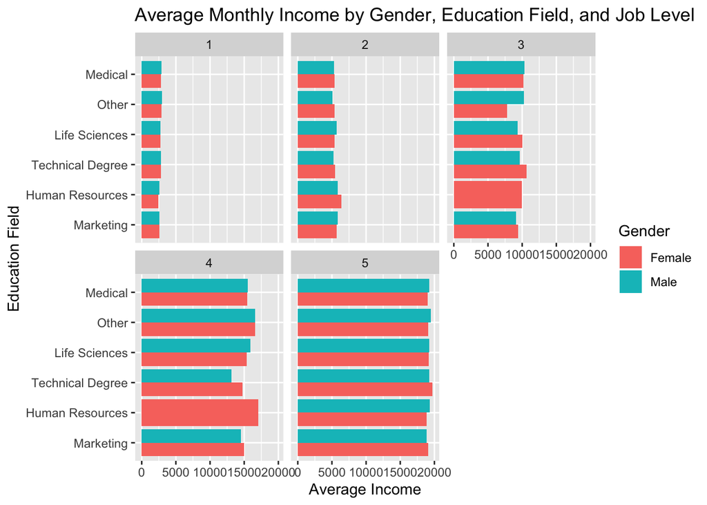

```r
gg<-ggplot(at_sum2,aes(x=reorder(EducationField,inc_avg),
                      y=inc_avg,
                      fill=Gender))
## Bar plot, with unstacked (dodge)
 gg<-gg+geom_bar(stat="identity",position="dodge")
## Separate out by Job Level
gg<-gg+facet_wrap(~JobLevel)
gg<-gg+ylab("Average Income")+xlab("Education Field")
## Change orientation to sideways
gg<-gg+coord_flip()
gg3<-gg+ggtitle("Average Monthly Income by Gender, Education Field, and Job Level")
## Print
gg3
```